# ACOR Aleutians Catch Data Plot

Kalin Seaton, Ruby Moon Consulting

2026-02-23

## Introduction and Instructions

- **Alaska.shp**
- **Catch_Data.csv**: Locations, years, catch data with one column for each hatchery and the offsets (in meters) for plotting the pie charts.
- **Hatcheries.csv**: Locations of hatcheries. Hatchery name must match with columns in Catch_Data.csv but need not include all the columns (e.g., no point for UNK or WILD). Offsets are in meters.
- **Land_Labels.csv**: A list of labels for land AOIs such as Alaska Peninsula. Includes size and angle. Coordinates (degrees) are center of label.
- **Water_Labels.csv**: A list of labels for water AOIs. Includes size and angle. Coordinates (degrees) are center of label.
- **Sites.csv**: These are the bays. Used for plotting bay locations as points and for labeling. Adjust offset in meters to adjust labels.

## Methods

- Loaded data from .csv file called “Catch_Data.csv” derived from original “Hatch_bar_site.xlsx” delivered to RMC on 20260125.
- Various .csv files loaded that contain names and coordinates for catch data, bay sites, hatchery, land and water labels.
- Note that land and water .csv files ONLY contain one set of coordinates (center of labels), but the rest have 2 sets of coordinates: one for the actual position of the site and one with the offset for the label (sites) or chart (catch_data).
- All data projected to WGS84 Web Mercator Auxiliary Sphere to have equal dimensions in x and y for plotting round pie graphs (appear oval in straight WGS84)
- Loaded Alaska boundary from shapefile Alaska.shp.
- Separated 2 years of catch data and make year-specific labels with sample sizes.
- Convert data values and make pies
- Calculate extent and placement for year labels in facets
- Plot 2-facet map with pie charts. This appears in the Output folder as “Aleutians_Catch_Map_YYYYMMDD_HHMMSS.png”.

## Plot

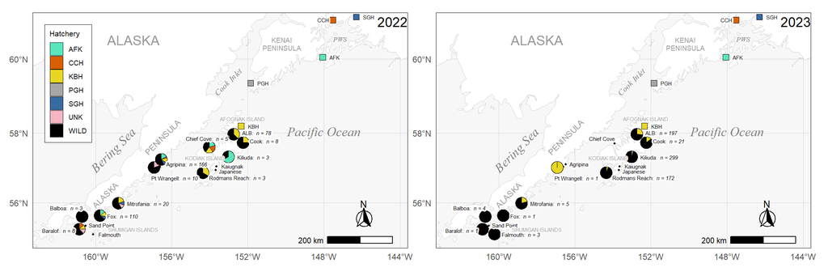

```r
plot(aleutians_catch_map)
```

## Discussion

This map was projected in WGS84 Web Mercator (Auxillary Sphere) which is a common projection for Google and ArcGIS Online. The similarity in scale for x and y provide a more circular pie shape than an un-projected WGS84 map but can create significant distortion away from the equator. Because of this, this map should not be used for navigation or measuring distances as they are somewhat distorted. Hatchery and bay (catch) coordinates used to make this map were provided by ACOR and assumed to be in WGS84 datum. The Alaska.shp shapefile is a general outline provided by ESRI (Redlands, CA) and is generalized for use at a scale of 1:500,000 and higher (i.e., continent-level mapping). Hatchery data was provided by ACOR specifically for use in this figure and is not authorized for use in any other format without their permission.